# Analysis of Pakistan Cricket (Men's) Team in T20is (2021-2024)

#### Brief Introduction to cricket for the context of this project

Cricket is a very common if not the most common sport in the Asian subcontinent. It includes two teams (of 11 players) each taking turns 'batting' and 'bowling' and for a certain number of overs (Each over is 6 balls, so the number of overs is essentially how many balls/deliveries each team will get to bat - and make as many runs as possible.) Whichever team has made more runs at the end of the game wins the game. The total number of overs each team gets to bat is dependant on the format of the game. T20i is one of the formats in which each team gets 20 overs (or 20x6=120 balls). This will be the format that is the focus of this project. I will be conducting an analysis of Pakistan's Cricket team's performance in the T20i format in the 2021-present period. (Starting 2021 since there was an overhaul of the team and new group of players were put into the team with most of them playing consistently until now.)

The analysis of the Pakistan cricket will be done in three parts with some goals in mind. The goals of this analysis project are to find out the following:

1. How has Pakistan's performance been in home games compared to away games? Has the team's performance changed throughout the years?
2. What type of player roles are there on the team? Are players performing as per there role and are there any takeaways that tell us how the player roles have been affecting the team's performance?
3. Who has been the most valuable player that contributed to Pakistan's victories in the analysis period.

Before starting the analysis the following are general ideas that people have with regards to the 3 goals mentioned above (these ideas are taken from news articles, sports columns or cricket discussion forums mentioned in the references below):

1. Teams playing at home have a significant advantage. Not just because of home crowd support which spurs the players on but also since the home team is in charge of curating the pitch (which affects the bounce, spin and speed of the ball after bouncing before the batsmen hits it) and teams normally prepare the pitch according to their strengths. $^{[1]}$
2. People think Pakistan has too many 'anchors' in their batting side. (Will be explained in more detailed later in Part 2) $^{[2]}$
3. Babar Azam is considered to be the best player by many and was ranked #1 by the ranking committee for a considerable time during the analysis period. $^{[3]}$

I will look to answer the questions posed in this project which should also answer whether or not the general ideas people have of Pakistan cricket are correct.

Notes:  
All data was taken from https://www.espncricinfo.com/  
Data was taken on 28th November, 2024 (Any stats after this date are not included)  
Any time a game is mentioned it can be assumed it is a Pakistan game in the T20i format.

References to intial assumptions:  
[1] : https://www.espncricinfo.com/story/michael-jeh-it-s-home-advantage-not-doctored-pitches-772595  
[2] https://ppforum.pakpassion.net/threads/difficult-to-play-an-anchor-role-in-t20s-sometimes-it-looks-very-embarrassing-mohammad-rizwan.309502/#google_vignette  
[3] https://www.gulftoday.ae/Sport/2022/06/29/Babar-overtakes-Kohli-for-most-number-of-days-as-No-1-in-T20s

## Part 1 - Team Performance

The first step is to import all the libraries (or functions) that will be required in this notebook. I import all of the required ones in the cell below to make it easier to see which libraries are used in this notebook.

```python
import pandas as pd
import matplotlib.pyplot as plt
import numpy as np
from sklearn.cluster import KMeans
from collections import defaultdict
```

Next it is required to import the dataset that will begin the inital analysis. 'Match_Results_2021-24' contains all the matches, the winner of the matches, the venue of the match and the match date for each match that took place from 2021 to present date (the day the data was retrieved from the website).

```python
match_results = pd.read_csv('Data Sets/Match_Results_2021-24.csv')
display(match_results.head())
# We can see from seeing the first few rows that the dataset includes the matches of every team that plays the game.
# For the purpose of this analysis I apply a filter below to include only the matches of the Pakistan team
pak = match_results[(match_results['Team 1']=='Pakistan') | (match_results['Team 2']=='Pakistan')]
# Some scheduled games did not happen (most of the time due to rain) and so they are not needed for the analysis
# Using the filter below I removed the games which were not played
pak = pak[~(pak['Winner']=='no result')]
display(pak.head(3))
display(pak.tail(3))
```

|  | Team 1 | Team 2 | Winner | Margin | Ground | Match Date | Scorecard |
| --- | --- | --- | --- | --- | --- | --- | --- |
| 0 | Ivory Coast | Sierra Leone | Sierra Leone | 168 runs | Lagos | Nov 23, 2024 | T20I # 2974 |
| 1 | Nigeria | St Helena | Nigeria | 118 runs | Lagos | Nov 23, 2024 | T20I # 2975 |
| 2 | Qatar | Cambodia | Qatar | 48 runs | Doha | Nov 23, 2024 | T20I # 2973 |
| 3 | Botswana | Eswatini | Botswana | 48 runs | Lagos | Nov 23, 2024 | T20I # 2972 |
| 4 | Bahrain | Bhutan | Bahrain | 90 runs | Doha | Nov 23, 2024 | T20I # 2970 |

|  | Team 1 | Team 2 | Winner | Margin | Ground | Match Date | Scorecard |
| --- | --- | --- | --- | --- | --- | --- | --- |
| 16 | Australia | Pakistan | Australia | 7 wickets | Hobart | Nov 18, 2024 | T20I # 2959 |
| 21 | Australia | Pakistan | Australia | 13 runs | Sydney | Nov 16, 2024 | T20I # 2954 |
| 27 | Australia | Pakistan | Australia | 29 runs | Brisbane | Nov 14, 2024 | T20I # 2948 |

|  | Team 1 | Team 2 | Winner | Margin | Ground | Match Date | Scorecard |
| --- | --- | --- | --- | --- | --- | --- | --- |
| 1853 | Pakistan | South Africa | Pakistan | 4 wickets | Lahore | Feb 14, 2021 | T20I # 1122 |
| 1854 | Pakistan | South Africa | South Africa | 6 wickets | Lahore | Feb 13, 2021 | T20I # 1121 |
| 1855 | Pakistan | South Africa | Pakistan | 3 runs | Lahore | Feb 11, 2021 | T20I # 1120 |

After cleaning and filtering the dataset to include only Pakistan's games that actually happened (not just scheduled). I start getting data values for the wins and losses of the team overall, in home games & in away games.

```
The below charts show the Win-Loss ratio of the Pakistan Cricket team in T20i's in Home & Away Games:
```

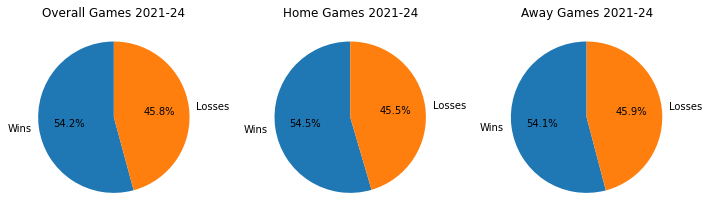

```python
overall_games = pak.shape[0]
overall_wins = pak[pak['Winner']=='Pakistan'].shape[0]
overall_loses = overall_games - overall_wins
overall_winpercentage = (overall_wins/overall_games)*100
#The home grounds that have hosted T20 cricket in Pakistan during 2021-24
pk_home_grounds = ['Karachi','Lahore','Rawalpindi']
home_games = pak[pak['Ground'].isin(pk_home_grounds)]
overall_homegames = home_games.shape[0]
home_wins = home_games[home_games['Winner']=='Pakistan'].shape[0]
home_loses = overall_homegames - home_wins
home_winpercentage = (home_wins/overall_homegames)*100

away_games = pak[~pak['Ground'].isin(pk_home_grounds)]
overall_awaygames = away_games.shape[0]
away_wins = away_games[away_games['Winner']=='Pakistan'].shape[0]
away_loses = overall_awaygames - away_wins
away_winpercentage = (away_wins/overall_awaygames)*100
#To visually see the win loss ratios I plotted them in pie charts as below
fig, axes = plt.subplots(1,3,figsize=(10,10))
chart_labels = ['Wins','Losses']
axes[0].pie(np.array([overall_wins,overall_loses]), labels=chart_labels, autopct='%1.1f%%', startangle=90)
axes[0].set_title('Overall Games 2021-24')
axes[1].pie(np.array([home_wins,home_loses]), labels=chart_labels, autopct='%1.1f%%', startangle=90)
axes[1].set_title('Home Games 2021-24')
axes[2].pie(np.array([away_wins,away_loses]), labels=chart_labels, autopct='%1.1f%%', startangle=90)
axes[2].set_title('Away Games 2021-24')

print('\nThe below charts show the Win-Loss ratio of the Pakistan Cricket team in T20i\'s in Home & Away Games:\n')
plt.tight_layout()
plt.show()
```

We can see from the pie charts that Pakistan has won a little over half the games played during the analysis period. One interesting thing to note is that the Home Games win-loss ratio is very similar to the Away Games win-loss ratio. This suggests that Pakistan does not have any significant advantage of playing in their backyard and having familiar and suitable conditions (pitches).

Next to see how the performance of the team has been changing throughout the years I need to extract the games based on the year they were played. From the cell below we can see that the 'Match Date' values were saved as 'object' data type so first I converted the data type to datetime then used filters to get the games played in each of the years from 2021-24.

```python
print('Intial \'Match Data\' datatype is:',pak['Match Date'].dtype)
pak['Match Date'] = pd.to_datetime(pak['Match Date'])
print('Converted \'Match Data\' datatype is:',pak['Match Date'].dtype)
pak['Year'] = pak['Match Date'].dt.year
games_21 = pak[pak['Year']==2021]
games_22 = pak[pak['Year']==2022]
games_23 = pak[pak['Year']==2023]
games_24 = pak[pak['Year']==2024]
```

```
Intial 'Match Data' datatype is: object
Converted 'Match Data' datatype is: datetime64[ns]
```

After filtering the games based on the year (in the previous cell) I calculated the wins & losses in each of the years then plotted pie charts to show the win-loss ratio. Since, the number of pie charts I had to plot increased I incorporated a for loop to try and reduce the number of lines that would be required to plot each chart.

```
The below charts show the Win-Loss ratio of the Pakistan Cricket team in T20i's from 2021 to 2024
```

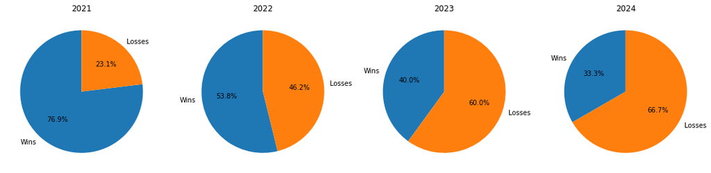

```python
wins_21 = games_21[games_21['Winner']=='Pakistan'].shape[0]
losses_21 = games_21.shape[0] - wins_21
winpercentage_21 = (wins_21/games_21.shape[0])*100

wins_22 = games_22[games_22['Winner']=='Pakistan'].shape[0]
losses_22 = games_22.shape[0] - wins_22
winpercentage_22 = (wins_22/games_22.shape[0])*100

wins_23 = games_23[games_23['Winner']=='Pakistan'].shape[0]
losses_23 = games_23.shape[0] - wins_23
winpercentage_23 = (wins_23/games_23.shape[0])*100

wins_24 = games_24[games_24['Winner']=='Pakistan'].shape[0]
losses_24 = games_24.shape[0] - wins_24
winpercentage_24 = (wins_24/games_24.shape[0])*100

print('\nThe below charts show the Win-Loss ratio of the Pakistan Cricket team in T20i\'s from 2021 to 2024 \n')
fig, axes = plt.subplots(1,4,figsize=(15,10))
chart_labels = ['Wins','Losses']
games = [[wins_21,losses_21],[wins_22,losses_22],[wins_23,losses_23],[wins_24,losses_24]]
year=['2021','2022','2023','2024']
for i in range(4):
    axes[i].pie(np.array(games[i]), labels=chart_labels, autopct='%1.1f%%', startangle=90)
    axes[i].set_title(year[i])
plt.tight_layout()
plt.show()
```

We can see from the piecharts that the win percentage started off high but then decreased in the following years. To see this trend in more detail I plotted a line graph below.

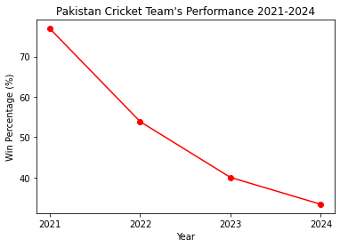

```python
y=[winpercentage_21,winpercentage_22,winpercentage_23,winpercentage_24]
plt.plot(year, y, marker='o', linestyle='-', color='r',)
plt.xlabel('Year')
plt.ylabel('Win Percentage (%)')
plt.title('Pakistan Cricket Team\'s Performance 2021-2024')
plt.show()
```

We can see from the line graph that Pakistan's performance has dwindled throughout the years of the analysis. Starting from a strong 76.9% win rate in 2021 the teams performance kept decreasing and has a win rate of just 33.3% in 2024.  
I wanted to show the summary of all the results in tabular form for quick access and easy reading so I did that using a pandas dataframe as in the below cell.

```python
summary = pd.DataFrame({
        "Number of Games":[overall_games,overall_homegames,overall_awaygames,games_21.shape[0],
                           games_22.shape[0],games_23.shape[0],games_24.shape[0]],
        "Wins":[overall_wins,home_wins,away_wins,wins_21,wins_22,wins_23,wins_24],
        "Losses":[overall_loses,home_loses,away_loses,losses_21,losses_22,losses_23,losses_24],
        "Win Percentage %":[overall_winpercentage,home_winpercentage,away_winpercentage,
                         winpercentage_21,winpercentage_22,winpercentage_23,winpercentage_24]
})

summary.rename(index={0: "Overall", 1: "Home",2:"Away",3:"2021",4:"2022",
                      5:"2023", 6:"2024"},inplace=True)
summary['Win Percentage %']=summary['Win Percentage %'].round(2)
print('\n The table below shows the summary of Pakistan\'s performance from 2021 to 2024:')
display(summary)
```

```
 The table below shows the summary of Pakistan's performance from 2021 to 2024:
```

|  | Number of Games | Wins | Losses | Win Percentage % |
| --- | --- | --- | --- | --- |
| Overall | 83 | 45 | 38 | 54.22 |
| Home | 22 | 12 | 10 | 54.55 |
| Away | 61 | 33 | 28 | 54.10 |
| 2021 | 26 | 20 | 6 | 76.92 |
| 2022 | 26 | 14 | 12 | 53.85 |
| 2023 | 10 | 4 | 6 | 40.00 |
| 2024 | 21 | 7 | 14 | 33.33 |

## Part 2 - Player Roles

In this part I will look to explore the roles in the Pakistan team setup and see if I can determine how effective the players are in executing their roles. The two main types of players that are in a cricket team are batsmen and bowlers. (Each type has a variant of roles which I will explain later) To start I will use two datasets 'Batting_Stats' and 'Bowling_Stats' which contain few of the main statistics that are required for the analysis. Since these datasets have alot of data that I won't need for my analysis I will drop those columns to avoid confusion and to keep the dataset from being unnecessarily large. Finally I will merge the batting and bowling datasets into 1 'stats' dataset from which I can get whatever data I require.

```python
overall_batting = pd.read_csv('Data Sets/Batting_Stats.csv')
overall_bowling = pd.read_csv('Data Sets/Bowling_Stats.csv')
# Drop the columns which are unnecessary for this analysis.
overall_batting = overall_batting.drop(columns=['NO','BF','HS','100','50','0','4s','6s'])
overall_bowling = overall_bowling.drop(columns=['Span','Mat','Mdns','BBI','4','5'])
stats = pd.merge(overall_batting,overall_bowling,how='outer',on='Player',suffixes=('_batting', '_bowling'))
display(stats.head(6))
```

|  | Player | Span | Mat | Inns_batting | Runs_batting | Ave_batting | SR_batting | Inns_bowling | Overs | Runs_bowling | Wkts | Ave_bowling | Econ | SR_bowling |
| --- | --- | --- | --- | --- | --- | --- | --- | --- | --- | --- | --- | --- | --- | --- |
| 0 | Mohammad Rizwan | 2021-2024 | 78 | 73 | 3016 | 53.85 | 127.79 | - | - | - | - | - | - | - |
| 1 | Babar Azam | 2021-2024 | 82 | 77 | 2511 | 35.36 | 128.7 | - | - | - | - | - | - | - |
| 2 | Fakhar Zaman | 2021-2024 | 52 | 46 | 1010 | 23.48 | 132.02 | - | - | - | - | - | - | - |
| 3 | Iftikhar Ahmed | 2021-2024 | 55 | 46 | 810 | 21.31 | 126.56 | 21 | 43.1 | 292 | 7 | 41.71 | 6.76 | 37 |
| 4 | Shadab Khan | 2021-2024 | 58 | 33 | 496 | 19.84 | 146.31 | 52 | 183.4 | 1323 | 54 | 24.5 | 7.2 | 20.4 |
| 5 | Mohammad Nawaz (3) | 2021-2024 | 44 | 36 | 464 | 19.33 | 138.5 | 41 | 133.4 | 1021 | 38 | 26.86 | 7.63 | 21.1 |

Before exploring the batting roles in the team I will briefly describe them (and some metrics) for context:  
There are a number of ways a batsmen's performance can be evaluated but in my analysis I will be focusing on two metrics: Batting Average and Batting Strike Rate. Batting average is the average of how many runs a batsman scores every game and the batting strike rate is how quickly the batsman scores the runs. (The fewer the deliveries faced the higher the batting strike rate) In T20i games the batsmen look to score as quickly as possible since there are a limited number of deliveries they get to face before the other team gets to bat. In an ideal case scenario a batsman would both a high batting average and a high strike rate, however, that is unlikely since scoring quickly means the batsman is trying to hit more which gives the opponents a better chance of getting him out. This leads to two types of batsmen in a team: anchors and aggressor. Anchors play more conservatively and thus have a high average but this comes at the cost of having a lower strike rate. Aggresors play more aggressively and thus have a high strike at the cost of a lower batting average. Tail-enders are normally bowlers that have a different role in the team and thus they are not expected to have neither a high batting average nor high strike rate.

I will use kmeans to perform clustering of players to classify and see the number of anchors, aggressors and tailenders. Since the 'stats' dataset includes every player that has played for Pakistan in the analysis period I will use a filter to only include players that have played atleast 10 games to avoid skewing of data. (If a player has only played 1 game he could have performed amazingly well or terribly which would result in an inaccurate analysis) I tried different number of clusters to see how the groups are clumped in the graph and decided 5 clusters is a good number to separate the types of roles and also anomalies.

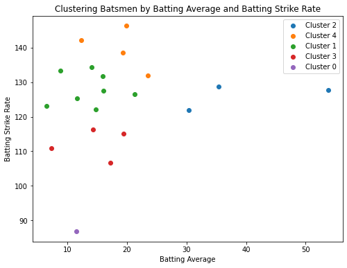

```python
batting_analysis = stats[stats['Inns_batting']!='-'].copy()
batting_analysis['Inns_batting'] = batting_analysis['Inns_batting'].astype(int)
batting_analysis = batting_analysis[['Player','Inns_batting','Ave_batting','SR_batting']]
batting_analysis = batting_analysis[batting_analysis['Inns_batting']>=10]
convert_dict = {'Ave_batting': float,'SR_batting': float}
batting_analysis = batting_analysis.astype(convert_dict)


kmeans = KMeans(n_clusters=5, random_state=1)
batting_analysis['Cluster'] = kmeans.fit_predict(batting_analysis[['Ave_batting','SR_batting']])
plt.figure(figsize=(8, 6))
for cluster in batting_analysis['Cluster'].unique():
    cluster_data = batting_analysis[batting_analysis['Cluster'] == cluster]
    plt.scatter(
        cluster_data['Ave_batting'],
        cluster_data['SR_batting'],
        label=f'Cluster {cluster}')

plt.xlabel('Batting Average')
plt.ylabel('Batting Strike Rate')
plt.title('Clustering Batsmen by Batting Average and Batting Strike Rate')
plt.legend()
plt.show()
```

Before continuing to the bowling analysis I will again give a brief description of the bowling roles and metrics used for analysis:  
Like batting, there are quite a number of ways a bowling performance can be analyzed. In my analysis I will be focusing on two metrics: Bowling economy and bowling strike rate. Bowling economy is how much runs a bowler gives in his over on average & bowling strike rate is how quickly the bowler can get the opposing team's batsman out (the number of balls per wicket). As opposed to the batting metrics, in this case a low economy and low bowling strike rate indicates a good performance. However, much like in batting, there are different types of bowlers: containment bowlers and strike bowlers. In an ideal scenario a bowler would take lots of wickets and give as few runs as possible but trying to get batsmen out has a risk of being hit more. Hence, containment bowlers normally have a low economy but high bowling strike rate and strike bowlers have a higher economy but lower bowling strike rate.

I used the same framework for this part as for the batting analysis. Using kmeans I grouped the bowlers who had played atleast 10 games into 3 categories: containment bowlers, strike bowlers and a third category which would be neither of the first two.

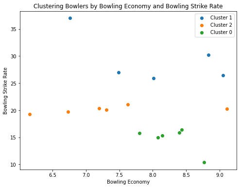

```python
bowling_analysis = stats[stats['Inns_bowling']!='-'].copy()
bowling_analysis['Inns_bowling'] = bowling_analysis['Inns_bowling'].astype(int)
bowling_analysis = bowling_analysis[['Player','Inns_bowling','Econ','SR_bowling']]
bowling_analysis = bowling_analysis[bowling_analysis['Inns_bowling']>=10]
convert_dict = {'Econ': float,'SR_bowling': float}
bowling_analysis = bowling_analysis.astype(convert_dict)


kmeans = KMeans(n_clusters=3, random_state=1)
bowling_analysis['Cluster'] = kmeans.fit_predict(bowling_analysis[['Econ','SR_bowling']])

plt.figure(figsize=(8, 6))
for cluster in bowling_analysis['Cluster'].unique():
    cluster_data = bowling_analysis[bowling_analysis['Cluster'] == cluster]
    plt.scatter(
        cluster_data['Econ'],
        cluster_data['SR_bowling'],
        label=f'Cluster {cluster}')

plt.xlabel('Bowling Economy')
plt.ylabel('Bowling Strike Rate')
plt.title('Clustering Bowlers by Bowling Economy and Bowling Strike Rate')
plt.legend()
plt.show()
```

## Part 3 - Most Valuable Player

In this part I will look to find the most valuable player of the team. To do this I will calculate the impact a player has on a match then calculate the average impact players have in the games Pakistan won. The player with the highest average impact contributing to wins will be considered the most valuable player. To start I will choose 10 players that have been playing the most - 5 batsmen and 5 bowlers who have the highest runs and highest number of wickets respectively.

```python
display(overall_batting.head())
display(overall_bowling.head())
```

|  | Player | Span | Mat | Inns | Runs | Ave | SR |
| --- | --- | --- | --- | --- | --- | --- | --- |
| 0 | Mohammad Rizwan | 2021-2024 | 78 | 73 | 3016 | 53.85 | 127.79 |
| 1 | Babar Azam | 2021-2024 | 82 | 77 | 2511 | 35.36 | 128.7 |
| 2 | Fakhar Zaman | 2021-2024 | 52 | 46 | 1010 | 23.48 | 132.02 |
| 3 | Iftikhar Ahmed | 2021-2024 | 55 | 46 | 810 | 21.31 | 126.56 |
| 4 | Shadab Khan | 2021-2024 | 58 | 33 | 496 | 19.84 | 146.31 |

|  | Player | Inns | Overs | Runs | Wkts | Ave | Econ | SR |
| --- | --- | --- | --- | --- | --- | --- | --- | --- |
| 0 | Haris Rauf | 62 | 227.4 | 1841 | 91 | 20.23 | 8.08 | 15 |
| 1 | Shaheen Shah Afridi | 55 | 197.3 | 1542 | 75 | 20.56 | 7.8 | 15.8 |
| 2 | Shadab Khan | 52 | 183.4 | 1323 | 54 | 24.5 | 7.2 | 20.4 |
| 3 | Mohammad Nawaz (3) | 41 | 133.4 | 1021 | 38 | 26.86 | 7.63 | 21.1 |
| 4 | Mohammad Wasim (1) | 29 | 92.1 | 751 | 36 | 20.86 | 8.14 | 15.3 |

Since the above dataset only shows the overall stats as an average of every game the players have played we need to get data for every game to be able to calculate the impact of a player in a game. Using the 10 top players from the above cell I got the datasets that have the performance data of every match in the below cell.

```python
Babar = pd.read_csv('Data Sets/Babar.csv')
Rizwan = pd.read_csv('Data Sets/Rizwan.csv')
Iftikhar = pd.read_csv('Data Sets/Iftikhar.csv')
Fakhar = pd.read_csv('Data Sets/Fakhar.csv')
Shadab_bat = pd.read_csv('Data Sets/Shadab(Batting).csv')
Shaheen = pd.read_csv('Data Sets/Shaheen.csv')
Rauf = pd.read_csv('Data Sets/Rauf.csv')
Shadab_bowl = pd.read_csv('Data Sets/Shadab(Bowling).csv')
Nawaz = pd.read_csv('Data Sets/Nawaz.csv')
Wasim = pd.read_csv('Data Sets/Wasim.csv')
display(Babar.head())
```

|  | Bat1 | Runs | BF | SR | 4s | 6s | Unnamed: 6 | Opposition | Ground | Start Date | Game |
| --- | --- | --- | --- | --- | --- | --- | --- | --- | --- | --- | --- |
| 0 | 0 | 0 | 1 | 0 | 0 | 0 | NaN | v South Africa | Lahore | 11-Feb-21 | T20I # 1120 |
| 1 | 5 | 5 | 4 | 125 | 1 | 0 | NaN | v South Africa | Lahore | 13-Feb-21 | T20I # 1121 |
| 2 | 44 | 44 | 30 | 146.66 | 5 | 1 | NaN | v South Africa | Lahore | 14-Feb-21 | T20I # 1122 |
| 3 | 14 | 14 | 14 | 100 | 3 | 0 | NaN | v South Africa | Johannesburg | 10-Apr-21 | T20I # 1145 |
| 4 | 50 | 50 | 50 | 100 | 5 | 0 | NaN | v South Africa | Johannesburg | 12-Apr-21 | T20I # 1146 |

```python
top_batsmen = {'Babar':Babar,'Rizwan':Rizwan,'Iftikhar':Iftikhar,'Fakhar':Fakhar,'Shadab_bat':Shadab_bat}
top_bowlers = {'Shaheen':Shaheen,'Rauf':Rauf,'Shadab_bowl':Shadab_bowl,'Nawaz':Nawaz,'Wasim':Wasim}
test = pak[['Winner','Scorecard']]
#Loop 1 to calculate the impact of batsmen
for i in top_batsmen:
    df = top_batsmen[i]
    df = (df[~((df['Bat1']=='TDNB')|(df['Bat1']=='DNB')|(df['SR']=='-'))])
    convert_dict = {'Runs':int,'BF':int,'SR':float}
    df = df.astype(convert_dict)
    df['Impact'] = (((df['Runs']/50)*0.85+(df['SR']/140)*0.75)*100).apply(lambda x: min(x, 100))
    test = pd.merge(test,df[['Game','Impact']],how='outer',left_on='Scorecard',right_on='Game').drop(columns=['Game'])\
    .rename(columns={'Impact': i})
#Loop 2 to calculate the impact of bowlers
for i in top_bowlers:
    df = top_bowlers[i]
    df = (df[~((df['Overs']=='-'))])
    convert_dict = {'Runs':int,'Wkts':int,'Econ':float}
    df = df.astype(convert_dict)
    df['Impact'] = (((7/df['Econ'])*0.75+(df['Wkts']/4)*0.85)*100).apply(lambda x: min(x, 100))
    test = pd.merge(test,df[['Game','Impact']],how='outer',left_on='Scorecard',right_on='Game').drop(columns=['Game'])\
    .rename(columns={'Impact': i})
test = test[test['Winner']=='Pakistan']
top_players=['Babar','Rizwan','Iftikhar','Fakhar','Shadab_bat','Shaheen','Rauf','Shadab_bowl','Nawaz','Wasim']
d = defaultdict(list)
#Loop to calculate the average impact of each of the players
for i in top_players:
    d[i]=("%.2f" % test[i].mean(skipna=True))
d= dict(d)
print("The average impact of the top players in the games that Pakistan won are as follows:")
print(d)
print('\n')
print('The player that had the highest average impact is',max(d, key=d.get))
```

```
The average impact of the top players in the games that Pakistan won are as follows:
{'Babar': '75.40', 'Rizwan': '90.45', 'Iftikhar': '75.05', 'Fakhar': '77.49', 'Shadab_bat': '82.56', 'Shaheen': '91.69', 'Rauf': '89.56', 'Shadab_bowl': '90.68', 'Nawaz': '90.38', 'Wasim': '89.20'}


The player that had the highest average impact is Shaheen
```

## Conclusion

After conducting the analysis I can say that I got a reply with regards to each of the general ideas mentioned at the start as well as some keytake aways regarding why the performance of the Pakistan team was as it was.  
To start in Part 1 we saw that Pakistan did not have any significant 'home ground advantage'. Playing in familiar conditions did not matter on average for the team as they had a very similar win-loss ratio in home games as compared to away games. We then saw that the performance of the team was declining through the years with 2021 having a 76.9% win percentage as compared to a dismal 33.3% win percentage in 2024.  
From Part 2 we saw the different types of batsmen and bowlers grouped accordingly. An interesting takeaway was that in both batsmen and bowlers there was a group of players that was not performing as they should be according to their roles. (Green cluster in the batting graph and blue cluster in the bowling graph) This could be one of the reasons that the Pakistan team's winning percentage has been dropping with time: some of the players in the team are not performing as per their roles.  
In Part 3 we saw the average impact of players in won games (or average contributions in a win) Contrary to popular belief the most valuable player was Shaheen Afridi and not Babar Azam as many people think. Another thing worth noticing is that the top batsmen had less impact on average compared to the bowlers in games won by Pakistan - this suggests that Pakistan wins games more due to good performance in bowling as compared to a good performance in batting. This could be an indication that the top batsmen need to perform better and may also be a reason for their declining win rate. (Top batsmen not performing as much as they should).  
This was my brief analysis of the performance of the Pakistan Cricket Team in T20is from 2021 to 2024. More in depth analysis can be carried out by including the specific opponents that Pakistan played against, how the performance varied against different oppositions and if we can identify any trends based on the strengths or weakness of opposing teams.

```python
print('The end.')
```

```
The end.
```